# Project 7 - AllLife Bank Customer Segmentation - Andrew Susanto

## Applying Hierarchical Clustering

```python
df.head()
```

|  | Avg_Credit_Limit | Total_Credit_Cards | Total_visits_bank | Total_visits_online | Total_calls_made | K_means_segments |
| --- | --- | --- | --- | --- | --- | --- |
| 0 | 100000 | 2 | 1 | 1 | 0 | 1 |
| 1 | 50000 | 3 | 0 | 10 | 9 | 0 |
| 2 | 50000 | 7 | 1 | 3 | 4 | 1 |
| 3 | 30000 | 5 | 1 | 1 | 4 | 1 |
| 4 | 100000 | 6 | 0 | 12 | 3 | 2 |

```python
#dropping of K_means_segments to prevent messing of data analysis in hierarchical clustering
df.drop('K_means_segments',axis = 1,inplace=True)
dfscaled.drop('K_means_segments',axis = 1,inplace=True)
```

```python
#list of distance metrics
distance_metrics = ["euclidean", "chebyshev", "mahalanobis", "cityblock"]

#list of linkage methods
linkage_methods = ["single", "complete", "average", "weighted"]

high_cophenet_corr = 0
high_dm_lm = [0, 0]

for dm in distance_metrics:
    for lm in linkage_methods:
        Z = linkage(dfscaled, metric=dm, method=lm)
        c, coph_dists = cophenet(Z, pdist(dfscaled))
        print(
            "Cophenetic correlation for {} distance and {} linkage is {}.".format(
                dm.capitalize(), lm, c
            )
        )
        if high_cophenet_corr < c:
            high_cophenet_corr = c
            high_dm_lm[0] = dm
            high_dm_lm[1] = lm
```

```
Cophenetic correlation for Euclidean distance and single linkage is 0.7391220243806552.
Cophenetic correlation for Euclidean distance and complete linkage is 0.8599730607972423.
Cophenetic correlation for Euclidean distance and average linkage is 0.8977080867389372.
Cophenetic correlation for Euclidean distance and weighted linkage is 0.8861746814895477.
Cophenetic correlation for Chebyshev distance and single linkage is 0.7382354769296767.
Cophenetic correlation for Chebyshev distance and complete linkage is 0.8533474836336782.
Cophenetic correlation for Chebyshev distance and average linkage is 0.8974159511838106.
Cophenetic correlation for Chebyshev distance and weighted linkage is 0.8913624010768603.
Cophenetic correlation for Mahalanobis distance and single linkage is 0.7058064784553606.
Cophenetic correlation for Mahalanobis distance and complete linkage is 0.5422791209801747.
Cophenetic correlation for Mahalanobis distance and average linkage is 0.8326994115042134.
Cophenetic correlation for Mahalanobis distance and weighted linkage is 0.7805990615142516.
Cophenetic correlation for Cityblock distance and single linkage is 0.7252379350252723.
Cophenetic correlation for Cityblock distance and complete linkage is 0.8731477899179829.
Cophenetic correlation for Cityblock distance and average linkage is 0.896329431104133.
Cophenetic correlation for Cityblock distance and weighted linkage is 0.8825520731498188.
```

```python
# printing the combination of distance metric and linkage method with the highest cophenetic correlation
print(
    "Highest cophenetic correlation is {}, which is obtained with {} distance and {} linkage.".format(
        high_cophenet_corr, high_dm_lm[0].capitalize(), high_dm_lm[1]
    )
)
```

```
Highest cophenetic correlation is 0.8977080867389372, which is obtained with Euclidean distance and average linkage.
```

```python
#continuing to explore different linkage methods with Euclidean distance only

# list of linkage methods
linkage_methods = ["single", "complete", "average", "centroid", "ward", "weighted"]

high_cophenet_corr = 0
high_dm_lm = [0, 0]

for lm in linkage_methods:
    Z = linkage(dfscaled, metric="euclidean", method=lm)
    c, coph_dists = cophenet(Z, pdist(dfscaled))
    print("Cophenetic correlation for {} linkage is {}.".format(lm, c))
    if high_cophenet_corr < c:
        high_cophenet_corr = c
        high_dm_lm[0] = "euclidean"
        high_dm_lm[1] = lm
```

```
Cophenetic correlation for single linkage is 0.7391220243806552.
Cophenetic correlation for complete linkage is 0.8599730607972423.
Cophenetic correlation for average linkage is 0.8977080867389372.
Cophenetic correlation for centroid linkage is 0.8939385846326323.
Cophenetic correlation for ward linkage is 0.7415156284827493.
Cophenetic correlation for weighted linkage is 0.8861746814895477.
```

```python
# printing the combination of distance metric and linkage method with the highest cophenetic correlation
print(
    "Highest cophenetic correlation is {}, which is obtained with {} linkage.".format(
        high_cophenet_corr, high_dm_lm[1]
    )
)
```

```
Highest cophenetic correlation is 0.8977080867389372, which is obtained with average linkage.
```

We see that the cophenetic correlation is maximum with Euclidean distance and average linkage. Let's see the dendrograms for the different linkage methods.

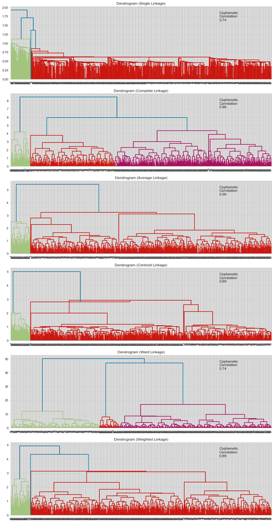

```python
# list of linkage methods
linkage_methods = ["single", "complete", "average", "centroid", "ward", "weighted"]

# lists to save results of cophenetic correlation calculation
compare_cols = ["Linkage", "Cophenetic Coefficient"]

# to create a subplot image
fig, axs = plt.subplots(len(linkage_methods), 1, figsize=(15, 30))

# We will enumerate through the list of linkage methods above
# For each linkage method, we will plot the dendrogram and calculate the cophenetic correlation
for i, method in enumerate(linkage_methods):
    Z = linkage(dfscaled, metric="euclidean", method=method)

    dendrogram(Z, ax=axs[i])
    axs[i].set_title(f"Dendrogram ({method.capitalize()} Linkage)")

    coph_corr, coph_dist = cophenet(Z, pdist(dfscaled))
    axs[i].annotate(
        f"Cophenetic\nCorrelation\n{coph_corr:0.2f}",
        (0.80, 0.80),
        xycoords="axes fraction",
    )
```

As the cophenetic correlation is maximum with Euclidean distance and average linkage methods, we will continue with the model. From the dendrogram above, 5 seems to be an appropriate number of clusters.

```python
#hierarchical clustering model creation/application
HCmodel = AgglomerativeClustering(n_clusters=5, affinity="euclidean", linkage="average")
HCmodel.fit(dfscaled)
```

```
AgglomerativeClustering(linkage='average', n_clusters=5)
```

```python
#assigning cluster labels to the dataset
dfscaled["HC_Clusters"] = HCmodel.labels_
df["HC_Clusters"] = HCmodel.labels_
```

```python
#checking cluster profile
cluster_profile = df.groupby("HC_Clusters").mean()

cluster_profile["count_in_each_segments"] = (
    df.groupby("HC_Clusters")["Total_Credit_Cards"].count().values
)
```

```python
#checking data distribution
df['HC_Clusters'].value_counts()
```

```
2    386
1    222
0     50
4      1
3      1
Name: HC_Clusters, dtype: int64
```

It seems that there are only 1 data each for cluster 3 and 4 using average linkage. Let's try using complete linkage as the cophenetic correlation score is close to the average linkage and as per dendogram, the data seems to be more distributed evenly across clusters. For complete linkage, 5 seems to be a good approximate value of number of clusters.

```python
#hierarchical clustering model creation/application
HCmodel = AgglomerativeClustering(n_clusters=5, affinity="euclidean", linkage="complete")
HCmodel.fit(dfscaled)
```

```
AgglomerativeClustering(linkage='complete', n_clusters=5)
```

```python
#assigning cluster labels to the dataset
dfscaled["HC_Clusters"] = HCmodel.labels_
df["HC_Clusters"] = HCmodel.labels_
```

```python
#checking cluster profile
cluster_profile = df.groupby("HC_Clusters").mean()

cluster_profile["count_in_each_segments"] = (
    df.groupby("HC_Clusters")["Total_Credit_Cards"].count().values
)
```

```python
#checking data distribution
df['HC_Clusters'].value_counts()
```

```
0    396
3    212
1     50
4      1
2      1
Name: HC_Clusters, dtype: int64
```

It seems that the distribution of the data is similar to the average linkage model. Hence, we will keep using average linkage due to the high value in cophenetic correlation score. This time, let's set the number of clusters to 3 to remove possibilities of a cluster having only one data.

```python
#hierarchical clustering model creation/application
HCmodel = AgglomerativeClustering(n_clusters=3, affinity="euclidean", linkage="average")
HCmodel.fit(dfscaled)
```

```
AgglomerativeClustering(linkage='average', n_clusters=3)
```

```python
#assigning cluster labels to the dataset
dfscaled["HC_Clusters"] = HCmodel.labels_
df["HC_Clusters"] = HCmodel.labels_
```

```python
#checking cluster profile
cluster_profile = df.groupby("HC_Clusters").mean()

cluster_profile["count_in_each_segments"] = (
    df.groupby("HC_Clusters")["Total_Credit_Cards"].count().values
)
```

```python
#checking data distribution
df['HC_Clusters'].value_counts()
```

```
2    396
0    214
1     50
Name: HC_Clusters, dtype: int64
```

```python
df.head()
```

|  | Avg_Credit_Limit | Total_Credit_Cards | Total_visits_bank | Total_visits_online | Total_calls_made | HC_Clusters |
| --- | --- | --- | --- | --- | --- | --- |
| 0 | 100000 | 2 | 1 | 1 | 0 | 0 |
| 1 | 50000 | 3 | 0 | 10 | 9 | 0 |
| 2 | 50000 | 7 | 1 | 3 | 4 | 2 |
| 3 | 30000 | 5 | 1 | 1 | 4 | 2 |
| 4 | 100000 | 6 | 0 | 12 | 3 | 1 |

```python
#displaying cluster profile
cluster_profile.style.highlight_max(color="lightgreen", axis=0)
```

| HC_Clusters | Avg_Credit_Limit | Total_Credit_Cards | Total_visits_bank | Total_visits_online | Total_calls_made | count_in_each_segments |
| --- | --- | --- | --- | --- | --- | --- |
| 0 | 12644.859813 | 2.350467 | 0.957944 | 3.621495 | 6.976636 | 214 |
| 1 | 141040.000000 | 8.740000 | 0.600000 | 10.900000 | 1.080000 | 50 |
| 2 | 32982.323232 | 5.469697 | 3.411616 | 1.010101 | 2.065657 | 396 |

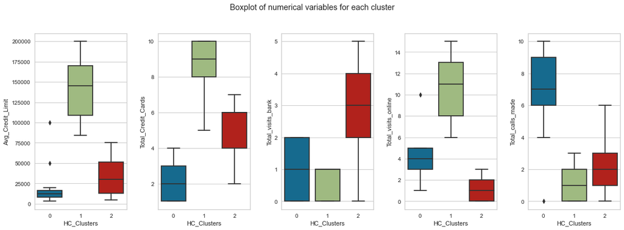

```python
fig, axes = plt.subplots(1, 5, figsize=(16, 6))
fig.suptitle("Boxplot of numerical variables for each cluster")
counter = 0
num_col = df.select_dtypes(include=np.number).columns.tolist()
for ii in range(5):
    sns.boxplot(ax=axes[ii], y=df[num_col[counter]], x=df["HC_Clusters"])
    counter = counter + 1

fig.tight_layout(pad=2.0)
```

## Actionable Insights & Recommendations

Based on the results, it can be seen that there are three different segments of the customers AllLife Bank had. Let's refer to the cluster names based on the results of hierarchical clustering.

The customers classified under cluster 0 are those with the lowest credit limit and lowest credit cards, and contact the bank mostly via calls. It is possible that these customers aren't breadwinners - they can register for credit cards but the main bank account is owned by the breadwinners (hence they can't really visit tellers as they don't have bank details, and can't contact online as they don't have userID and password). It is also possible that these customers are younger and do not have a lot on their savings yet. For this segment, possible actionable insights could include:

1. Maintaining a high level of customer satisfaction from customer service calls.
2. As they are comfortable with calls, it is also possible to contact them via calls to promote some bank products to ensure customer loyalty to the bank.

The customers classified under cluster 1 have a very high credit limit and amount of credit cards, and very likely to contact the bank online. It is possible that these are busy breadwinners that only have enough time to contact the bank online (as queuing/travelling to visit or calling the bank can be time consuming for them). Examples of these people are investment bankers (they earn a lot, but have very little time). It is very likely that these customers are loyal to the bank due to the high amount of credit limit and credit cards, and hence it is very important not to let these customers go. For this segment, possible actionable insights could include:

1. Improving the UI for online banking, whether by computer or phone. It is important to make sure these customers are comfortable using the online services.
2. Providing loyalty benefits to the customers, such as mileage points and offer them premium membership.

The customers classified under cluster 2 have a medium amount of credit limit and amount of credit cards, and likely to visit the bank physically. It seems possible that these are older customers that have a good amount of savings, yet not comfortable to use online services as well as calls as they could be prone to miscommunication. For this segment, possible actionable insights could include:

1. Provide excellent customer service on retail banks
2. Promote products that ensure savings for retirement
3. If there are lots of customers from this segment, it's possible to gain data on location and build bank branches that are close to their location.

Cluster 0 can be referred to as **non-breadwinners & new customers**. Cluster 1 can be referred to as **busy yet loyal breadwinners**. Cluster 2 can be referred to as **bank visitors**.